# Insurance customer churn prediction

Nico Henzel

2022-04-25

# 1 Plan

Anleitung Siehe https://www.kirenz.com/post/2021-02-17-r-classification-tidymodels/#boosted-tree-xgboost

Offene Punkte Siehe FOlien https://kirenz.github.io/data-science-r/docs/plan.html

Zusätzlich:

- Bewertungskriterien abdecken aus Slack
- Bewertungskriterien abdecken aus https://drive.google.com/file/d/1AsNHMnbEluH1ikwmp6ulBLqmmiHP3q98/view
- Am Schluss: Styling überarbeiten und Abbildungsverzeichnis erstellen
- Verweise in R Markdown nachschauen und Fette Textstellen als verweis markieren
- Dashboard erstellen mit Implementierung der neuen Daten. Inhalte:  
  Customer churn distribution (pie Chart) INTERAKTIVE ABBILDUNG MUSS DEFINIERT WERDEN! z.B. Korrelation der einzelnen Features mit churn rate darstellen, nach Features und relationshöhe filterbar. Tabelle mit Zeilen, die als Churn predicted wurden

## 1.1 Use case

The goal for this project is to train a classification algorithm with anonymized insurance contract data in order to predict the churn of insurance customers (whether the insurance company will lose a customer or not). Since the outcome is categorial (customer stays or leaves) and the churn in the available training data is labeled, we face a supervised learning problem that can be solved with a classification model.  
In order to measure the performance of different classfication models, the F1-Score will serve as a metric.

A potential use case, where these insights could be applied, is: Any insurance company wants to improve (or at least not decrease) their customer loyalty. If the insurance case handlers could understand why a customer quits a contract and more importantly if a customer is close to quitting an ongoing contract, they could start countermeasures in order to improve customer service and maybe keep the customer. The output from this model could be provided as information within a dashboard, or implemented into existing applications which display contract information to the case handler. This information can then be used to make further decisions by the case handlers. The visualization in this project will be realized throug a dashboard.

## 1.2 Metrics

The performance of the different models will be measured by the ROC-curve and the Area under the ROC-curve (ROC-AUC). These are the most important metrics since we want to make sure that our model predicts more True negatives (= Churn) than False positives in order to give the case handlers the best overview of possible churn candidates. Additionally we will check some other performance metrics like recall, precision, sensitivity, F1-Score to evaluate our models and hyperparameter tuning.

The model is successful when:

- Visualized recommendations allow case handlers to identify potential churn and get in contact with customers.

# 2 Data understanding

## 2.1 Import

Load training and test dataset (provided from kaggle - see **https://www.kaggle.com/datasets/k123vinod/insurance-churn-prediction-weekend-hackathon**)

Note: the training dataset will be used to fit the model. The provided test dataset will be treated as new data to simulate the models performance, since the data is unlabeled.

```r
LINK_train <-
  "https://raw.githubusercontent.com/NicoHenzel/Insurance-Churn-Prediction/main/Data/Train.csv"

new_training_data <-
  read_csv(LINK_train)
LINK_new <-
  "https://raw.githubusercontent.com/NicoHenzel/Insurance-Churn-Prediction/main/Data/Test.csv"

new_data <-
  read_csv(LINK_new)
```

## 2.2 First look

Look at the first rows from each dataframe.

```r
new_training_data %>%
  slice_head(n=5) %>%
  gt()
```

| feature_0 | feature_1 | feature_2 | feature_3 | feature_4 | feature_5 | feature_6 | feature_7 | feature_8 | feature_9 | feature_10 | feature_11 | feature_12 | feature_13 | feature_14 | feature_15 | labels |
| --- | --- | --- | --- | --- | --- | --- | --- | --- | --- | --- | --- | --- | --- | --- | --- | --- |
| -0.2765146 | -0.4244288 | 1.3449969 | -0.01228261 | 0.07622994 | 1.0766475 | 0.1821975 | 3 | 0 | 1 | 0 | 0 | 0 | 0 | 10 | 2 | 1 |
| 0.8535731 | 0.1509913 | 0.5038918 | -0.97917917 | -0.56935064 | -0.4114531 | -0.2519404 | 4 | 1 | 2 | 0 | 1 | 0 | 0 | 0 | 3 | 0 |
| 0.9477471 | -0.1738321 | 1.8256285 | -0.70347774 | 0.07622994 | -0.4114531 | -0.2519404 | 6 | 1 | 2 | 0 | 0 | 0 | 0 | 5 | 3 | 0 |
| 0.8535731 | -0.3814037 | 0.9845233 | -0.03946444 | -0.56935064 | -0.4114531 | -0.2519404 | 4 | 0 | 2 | 0 | 1 | 0 | 0 | 5 | 3 | 0 |
| 1.3244430 | 1.5905268 | -1.1783185 | -0.09771123 | -0.24656035 | -0.4114531 | -0.2519404 | 0 | 1 | 1 | 0 | 0 | 0 | 0 | 8 | 3 | 0 |

```r
new_data %>%
  slice_head(n=5) %>%
  gt()
```

| feature_0 | feature_1 | feature_2 | feature_3 | feature_4 | feature_5 | feature_6 | feature_7 | feature_8 | feature_9 | feature_10 | feature_11 | feature_12 | feature_13 | feature_14 | feature_15 |
| --- | --- | --- | --- | --- | --- | --- | --- | --- | --- | --- | --- | --- | --- | --- | --- |
| 0.5710512 | 0.4068430 | 0.9845233 | 0.0110161 | -0.56935064 | -0.4114531 | -0.2519404 | 0 | 1 | 1 | 0 | 0 | 0 | 0 | 11 | 3 |
| -1.1240804 | -0.1669349 | 0.5038918 | -0.3229321 | 0.72181052 | 0.5473231 | 0.1821975 | 0 | 2 | 1 | 0 | 0 | 0 | 0 | 5 | 1 |
| 0.4768772 | 0.1450794 | -0.5775291 | -0.6918284 | -0.24656035 | -0.4114531 | -0.2519404 | 0 | 1 | 1 | 0 | 0 | 0 | 0 | 1 | 3 |
| 1.6069650 | -0.4474193 | 1.8256285 | -0.9830623 | 7.17761632 | -0.4114531 | -0.2519404 | 1 | 1 | 0 | 0 | 1 | 0 | 0 | 5 | 3 |
| -0.9357324 | -0.3646534 | -1.1783185 | -0.3229321 | 0.07622994 | -0.4114531 | -0.2519404 | 8 | 2 | 1 | 0 | 1 | 0 | 2 | 8 | 3 |

This gives us the following informations:

1. The data seems to be clean already. Further information will be gathered in **Format Data** section.
2. The datasets are divided by a 75/25 split. The dimensions for both dataframes are the following:
- Training set:  
  observations = 33908  
  variables = 17
- New dataset:  
  observations = 11303  
  variables = 16
3. The labels column is a boolean (1 or 0) which only appears in the training data set.  
   This variable can be seen as the indicator for churning, since the column doesn’t appear in the given test data.  
   This also means, that the provided test data can be trated as new data to simulate a churn prediction on.

## 2.3 Clean data

The datasets are already clean (lowercase column names without spaces and no special characters). This makes it easier for us, since no data cleaning needs to be performed.

## 2.4 Format data

Next we will be inspecting the given data structure and check if there are any missing values in both datasets.

```r
glimpse(new_training_data)
```

```
## Rows: 33,908
## Columns: 17
## $ feature_0  <dbl> -0.276514595, 0.853573137, 0.947747115, 0.853573137, 1.3244~
## $ feature_1  <dbl> -0.42442881, 0.15099126, -0.17383206, -0.38140368, 1.590526~
## $ feature_2  <dbl> 1.34499695, 0.50389181, 1.82562845, 0.98452332, -1.17831846~
## $ feature_3  <dbl> -0.012282614, -0.979179166, -0.703477740, -0.039464445, -0.~
## $ feature_4  <dbl> 0.07622994, -0.56935064, 0.07622994, -0.56935064, -0.246560~
## $ feature_5  <dbl> 1.0766475, -0.4114531, -0.4114531, -0.4114531, -0.4114531, ~
## $ feature_6  <dbl> 0.1821975, -0.2519404, -0.2519404, -0.2519404, -0.2519404, ~
## $ feature_7  <dbl> 3, 4, 6, 4, 0, 4, 9, 9, 8, 7, 1, 1, 11, 10, 9, 7, 6, 9, 8, ~
## $ feature_8  <dbl> 0, 1, 1, 0, 1, 1, 1, 1, 2, 1, 1, 1, 1, 2, 0, 2, 2, 2, 2, 2,~
## $ feature_9  <dbl> 1, 2, 2, 2, 1, 1, 1, 1, 2, 1, 1, 0, 0, 1, 1, 1, 2, 1, 1, 1,~
## $ feature_10 <dbl> 0, 0, 0, 0, 0, 0, 0, 0, 0, 0, 0, 0, 0, 0, 0, 0, 0, 0, 0, 0,~
## $ feature_11 <dbl> 0, 1, 0, 1, 0, 0, 1, 1, 1, 0, 1, 0, 0, 1, 0, 1, 0, 1, 0, 1,~
## $ feature_12 <dbl> 0, 0, 0, 0, 0, 0, 0, 0, 0, 0, 1, 0, 0, 0, 0, 0, 0, 0, 0, 0,~
## $ feature_13 <dbl> 0, 0, 0, 0, 0, 0, 0, 0, 0, 0, 2, 1, 0, 2, 0, 0, 2, 0, 0, 0,~
## $ feature_14 <dbl> 10, 0, 5, 5, 8, 10, 5, 5, 8, 8, 6, 5, 5, 8, 1, 0, 6, 0, 8, ~
## $ feature_15 <dbl> 2, 3, 3, 3, 3, 1, 3, 3, 3, 3, 3, 3, 3, 3, 3, 3, 3, 1, 1, 3,~
## $ labels     <dbl> 1, 0, 0, 0, 0, 1, 0, 0, 0, 0, 0, 0, 0, 0, 1, 0, 0, 0, 1, 0,~
```

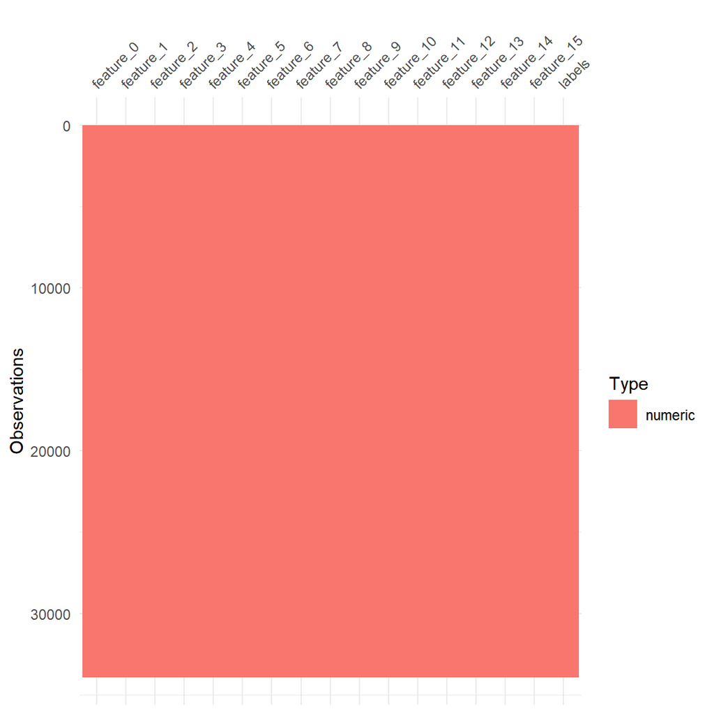

```r
vis_dat(new_training_data)
```

```r
glimpse(new_data)
```

```
## Rows: 11,303
## Columns: 16
## $ feature_0  <dbl> 0.57105120, -1.12408039, 0.47687723, 1.60696496, -0.9357324~
## $ feature_1  <dbl> 0.40684299, -0.16693490, 0.14507941, -0.44741934, -0.364653~
## $ feature_2  <dbl> 0.9845233, 0.5038918, -0.5775291, 1.8256285, -1.1783185, 0.~
## $ feature_3  <dbl> 0.01101610, -0.32293211, -0.69182838, -0.98306229, -0.32293~
## $ feature_4  <dbl> -0.56935064, 0.72181052, -0.24656035, 7.17761632, 0.0762299~
## $ feature_5  <dbl> -0.4114531, 0.5473231, -0.4114531, -0.4114531, -0.4114531, ~
## $ feature_6  <dbl> -0.2519404, 0.1821975, -0.2519404, -0.2519404, -0.2519404, ~
## $ feature_7  <dbl> 0, 0, 0, 1, 8, 1, 0, 4, 4, 10, 4, 0, 8, 1, 10, 3, 10, 4, 9,~
## $ feature_8  <dbl> 1, 2, 1, 1, 2, 2, 2, 0, 1, 1, 2, 0, 2, 1, 1, 0, 2, 2, 0, 1,~
## $ feature_9  <dbl> 1, 1, 1, 0, 1, 3, 1, 1, 2, 1, 2, 1, 1, 1, 0, 1, 1, 2, 2, 2,~
## $ feature_10 <dbl> 0, 0, 0, 0, 0, 0, 0, 0, 0, 0, 0, 0, 0, 0, 0, 0, 0, 0, 0, 0,~
## $ feature_11 <dbl> 0, 0, 0, 1, 1, 0, 1, 1, 0, 0, 1, 1, 1, 1, 0, 0, 0, 1, 0, 1,~
## $ feature_12 <dbl> 0, 0, 0, 0, 0, 0, 0, 0, 0, 0, 0, 0, 0, 0, 0, 0, 0, 0, 0, 0,~
## $ feature_13 <dbl> 0, 0, 0, 0, 2, 2, 0, 2, 0, 0, 2, 2, 2, 0, 0, 0, 0, 0, 0, 2,~
## $ feature_14 <dbl> 11, 5, 1, 5, 8, 6, 3, 8, 5, 0, 8, 8, 8, 8, 3, 9, 1, 1, 9, 6~
## $ feature_15 <dbl> 3, 1, 3, 3, 3, 3, 0, 3, 3, 3, 3, 3, 3, 0, 3, 3, 3, 3, 3, 3,~
```

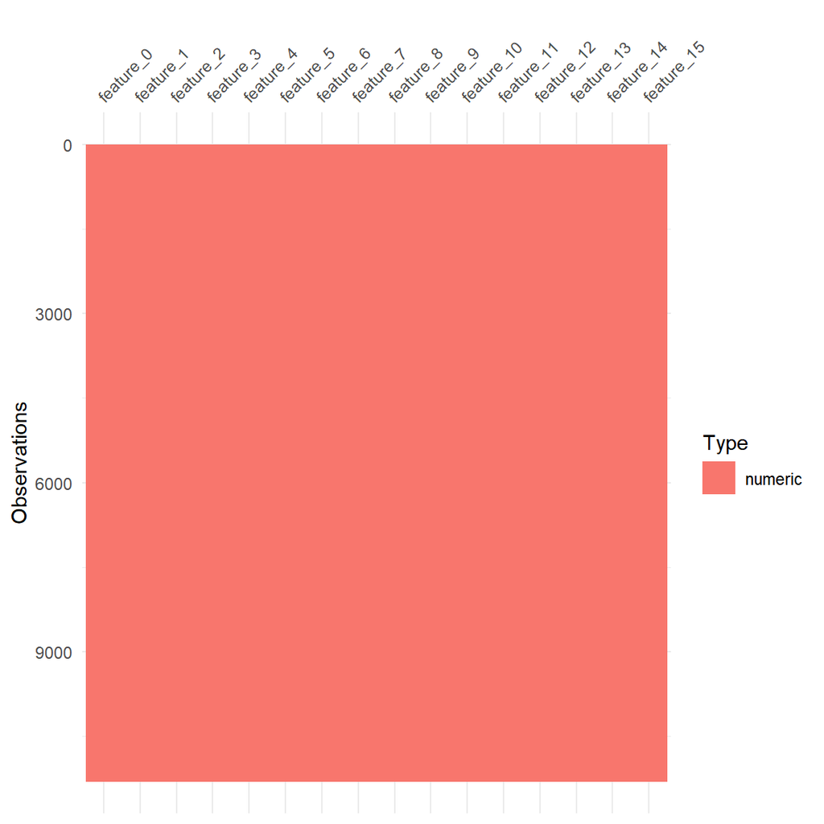

```r
vis_dat(new_data)
```

```r
na_training <-
  sum(is.na(new_training_data))
na_new <-
  sum(is.na(new_data))
```

We can see that:

1. The datatype for every variable (feature column) in both datasets is double, although there are variables that only hold integer values (feature_7 to feature_15). In the **Data exploration** section we will inspect the difference between integer and float variables.
2. There are 0 missing values in the training and 0 in the test dataset.
3. The labels column is formatted as numeric (dbl). It should be a factor since it is a categorial variable with two levels (1 or 0).  
   Let’s take a look at the labels variable:

```r
new_training_data %>%
  count(labels) %>%
  gt
```

| labels | n |
| --- | --- |
| 0 | 29941 |
| 1 | 3967 |

First the labels column will be renamed to churn. The column is then transformed into a factor type. This is needed for running the classification algorith.

```r
# Rename labels
df_train <-
  new_training_data %>%
  rename(churn = labels) %>%
# Change column type to factor
  mutate(
    churn = as.factor(churn)
  )
```

This way the churn is more accurately represented by thechurn variable:

```r
df_train %>%
  count(churn,
        name ="churn_total") %>%
  mutate(percent = churn_total/sum(churn_total)*100,
         percent = round(percent, 2)) %>%
 gt() %>%
  tab_header(
    title = "Insurance customers churn rate ",
    subtitle = "Anonymized training sample"
  ) %>%
  cols_label(
    churn = "Churn",
    churn_total = "Amount",
    percent = "Percent"
  )
```

Insurance customers churn rate

Anonymized training sample

| Churn | Amount | Percent |
| --- | --- | --- |
| 0 | 29941 | 88.3 |
| 1 | 3967 | 11.7 |

Note:  
No new variables will be created, since we work with anonymized data.  
The **Data exploration** section covers analysis and interpretation of the relations between the variables.

## 2.5 Data overview

```r
skim(df_train) %>%
  gt()
```

| skim_type | skim_variable | n_missing | complete_rate | factor.ordered | factor.n_unique | factor.top_counts | numeric.mean | numeric.sd | numeric.p0 | numeric.p25 | numeric.p50 | numeric.p75 | numeric.p100 | numeric.hist |
| --- | --- | --- | --- | --- | --- | --- | --- | --- | --- | --- | --- | --- | --- | --- |
| factor | churn | 0 | 1 | FALSE | 2 | 0: 29941, 1: 3967 | NA | NA | NA | NA | NA | NA | NA | NA |
| numeric | feature_0 | 0 | 1 | NA | NA | NA | -4.157719e-03 | 0.9997759 | -2.1599941 | -0.7473845 | -0.18234062 | 0.66522518 | 5.091402 | ▅▇▃▁▁ |
| numeric | feature_1 | 0 | 1 | NA | NA | NA | 2.583825e-03 | 1.0142678 | -3.0811485 | -0.4227866 | -0.29732404 | 0.02290117 | 33.094776 | ▇▁▁▁▁ |
| numeric | feature_2 | 0 | 1 | NA | NA | NA | -2.127901e-04 | 1.0008723 | -1.7791078 | -0.9380027 | 0.02326031 | 0.62404969 | 1.825628 | ▆▅▇▅▆ |
| numeric | feature_3 | 0 | 1 | NA | NA | NA | -5.287459e-05 | 1.0025117 | -1.0024779 | -0.6025167 | -0.30351652 | 0.23623698 | 18.094700 | ▇▁▁▁▁ |
| numeric | feature_4 | 0 | 1 | NA | NA | NA | -2.980493e-04 | 1.0037235 | -0.5693506 | -0.5693506 | -0.24656035 | 0.07622994 | 19.443647 | ▇▁▁▁▁ |
| numeric | feature_5 | 0 | 1 | NA | NA | NA | -4.651946e-03 | 0.9939836 | -0.4114531 | -0.4114531 | -0.41145311 | -0.41145311 | 8.127648 | ▇▁▁▁▁ |
| numeric | feature_6 | 0 | 1 | NA | NA | NA | -7.497738e-03 | 0.8026964 | -0.2519404 | -0.2519404 | -0.25194037 | -0.25194037 | 23.625644 | ▇▁▁▁▁ |
| numeric | feature_7 | 0 | 1 | NA | NA | NA | 4.336381e+00 | 3.2733763 | 0.0000000 | 1.0000000 | 4.00000000 | 7.00000000 | 11.000000 | ▇▅▂▂▅ |
| numeric | feature_8 | 0 | 1 | NA | NA | NA | 1.171051e+00 | 0.6067304 | 0.0000000 | 1.0000000 | 1.00000000 | 2.00000000 | 2.000000 | ▂▁▇▁▃ |
| numeric | feature_9 | 0 | 1 | NA | NA | NA | 1.225345e+00 | 0.7491039 | 0.0000000 | 1.0000000 | 1.00000000 | 2.00000000 | 3.000000 | ▂▇▁▅▁ |
| numeric | feature_10 | 0 | 1 | NA | NA | NA | 1.813731e-02 | 0.1334499 | 0.0000000 | 0.0000000 | 0.00000000 | 0.00000000 | 1.000000 | ▇▁▁▁▁ |
| numeric | feature_11 | 0 | 1 | NA | NA | NA | 5.555031e-01 | 0.4969172 | 0.0000000 | 0.0000000 | 1.00000000 | 1.00000000 | 1.000000 | ▆▁▁▁▇ |
| numeric | feature_12 | 0 | 1 | NA | NA | NA | 1.596673e-01 | 0.3663027 | 0.0000000 | 0.0000000 | 0.00000000 | 0.00000000 | 1.000000 | ▇▁▁▁▂ |
| numeric | feature_13 | 0 | 1 | NA | NA | NA | 6.394066e-01 | 0.8976269 | 0.0000000 | 0.0000000 | 0.00000000 | 2.00000000 | 2.000000 | ▇▁▁▁▃ |
| numeric | feature_14 | 0 | 1 | NA | NA | NA | 5.520497e+00 | 3.0032412 | 0.0000000 | 3.0000000 | 6.00000000 | 8.00000000 | 11.000000 | ▅▂▇▇▃ |
| numeric | feature_15 | 0 | 1 | NA | NA | NA | 2.562375e+00 | 0.9871483 | 0.0000000 | 3.0000000 | 3.00000000 | 3.00000000 | 3.000000 | ▁▁▁▁▇ |

## 2.6 Data split

Before exploring the data we perform a data split. The **Data exploration** will only be done on the training set. This is crucial so we don’t use any information from the training set in our model building phase. Although the data already comes with a 75/25 split the provided test data will not be used for model training since it is unlabeled and better suited to simulate new data.

```r
# Seeded split to provide the same split everytime the split is made to make sure we always use the same data for model training.
set.seed(42)
# Split the data with a 75/25 proportion in favor for the training set
data_split <-
  initial_split(
    df_train, # original training dataset
    prop = 3/4, # 75/25 split
    strata = churn # stratified on churn variable
    )
# Create the dataframes for training and testing
train_data <- training(data_split)
test_data <- testing(data_split)
```

## 2.7 Data exploration

In order to get a better understanding of the data and underlying relations between features, we plot the data in different ways.

### 2.7.1 Setup

We create a new dataframe to avoid altering the training dataset during the data exploration.

```r
explore_data <-
  train_data
```

Then we change the binary values to named values to represent the churn in order to make the plots easier to read (Using yes and no instead of 1 and 0).

```r
#Change column type to character to change values
explore_data <-
  explore_data %>%
  mutate(
    churn = as.character(churn)
  )
# Change values
explore_data$churn[explore_data$churn == "1"] <-
  "yes"
explore_data$churn[explore_data$churn == "0"] <-
  "no"
#Change column type back to factor
explore_data <-
  explore_data %>%
  mutate(
    churn = as.factor(churn)
  )
```

### 2.7.2 Churn distribution

The ratio of customers that have churned within the training data set is depicted below.

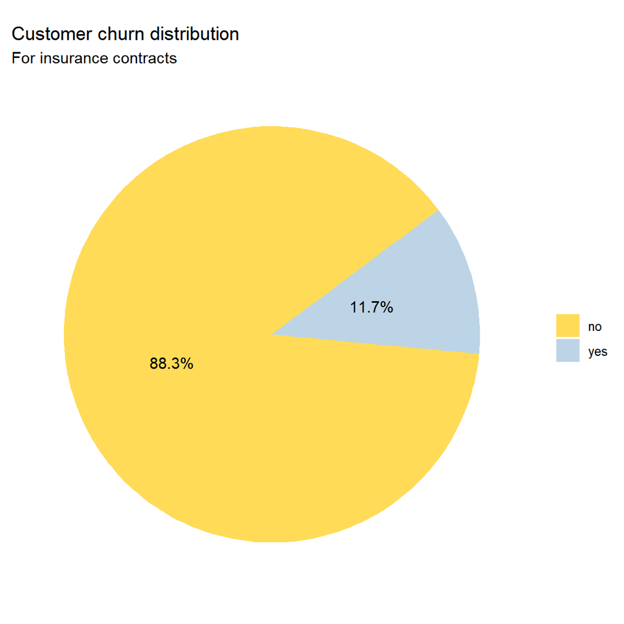

| churn | churn_total | percent |
| --- | --- | --- |
| no | 22455 | 88.3 |
| yes | 2975 | 11.7 |

```
##
##    no   yes
## 22455  2975
```

The data is imbalanced as nearly 90 % are labeled as not churning. We will compensate for this before performing hyperparameter tuning.

### 2.7.3 Correlation to churn

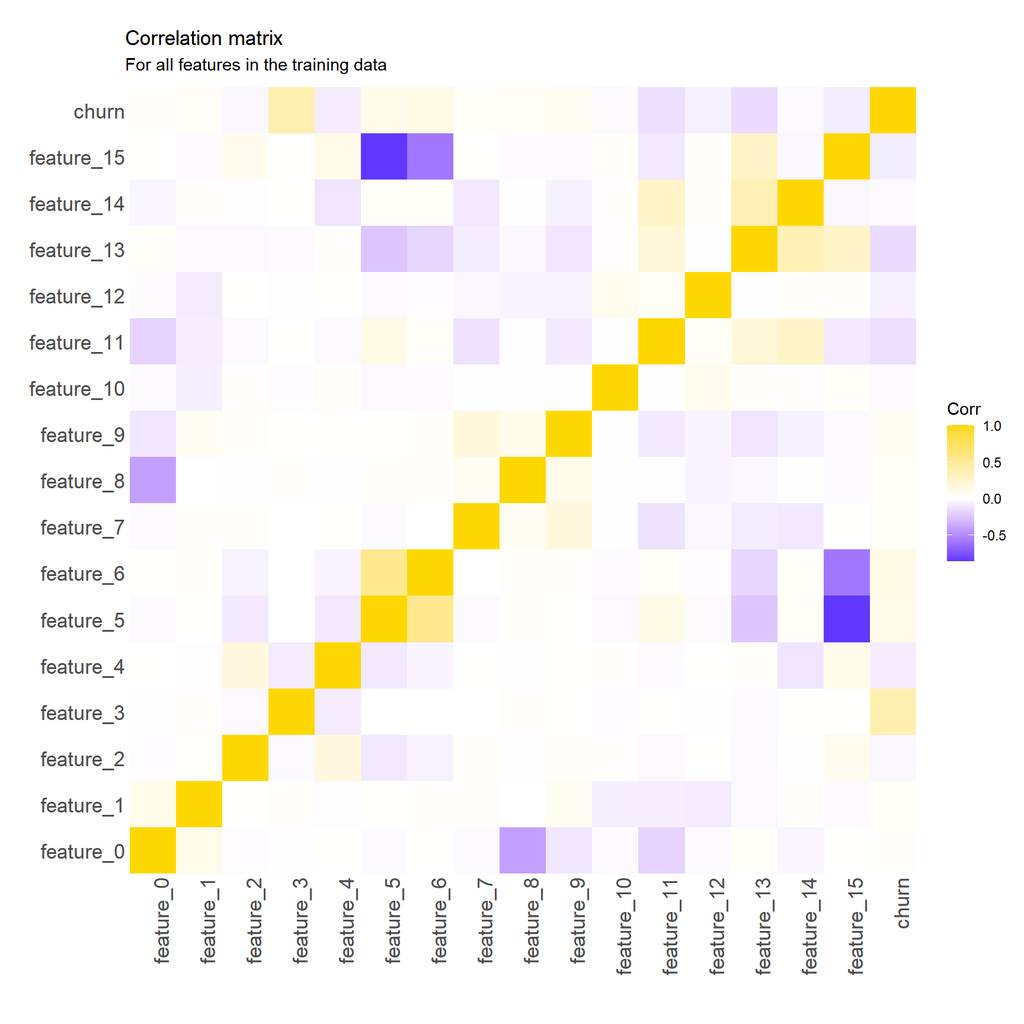

It is also useful to show the specific correlation of each feature to our churn variable:

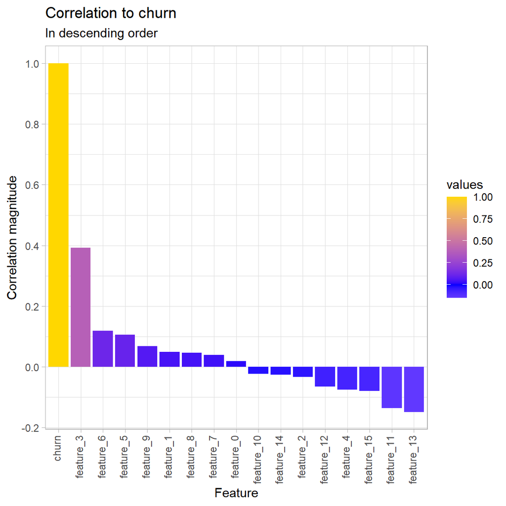

We can see that the correlation between churn and the other features is the following:

- It correlates not or very weak with most of the features
- feature_3 has a moderat positive correlation with churn.
- feature_5 & 6 correlate slightly positive.
- feature_11 & 13 correlate slightly negative.

To further inspect the relation between churn and other variables we will create plots for each variable.

### 2.7.4 Float Variables

We will start with boxplots and histograms for the float variables.

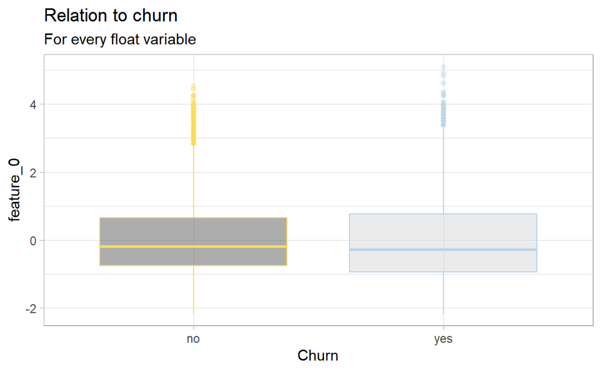

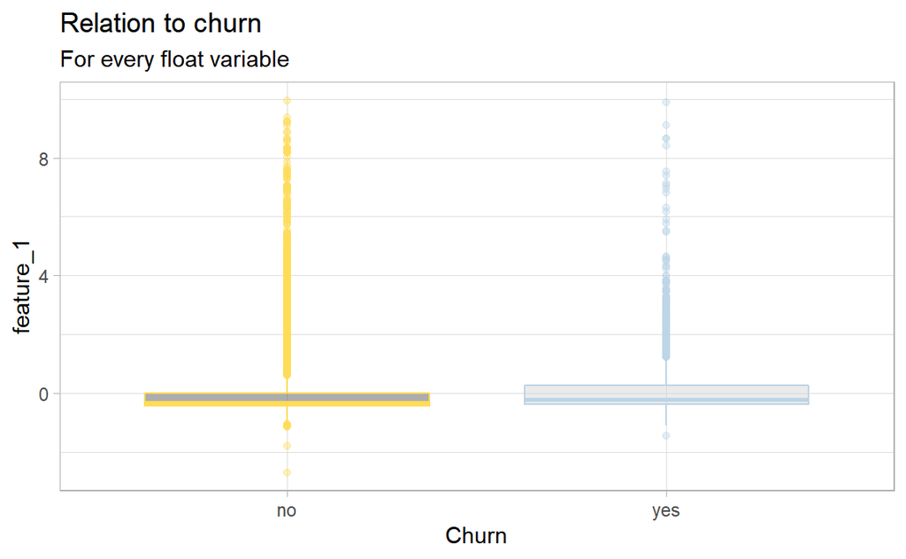

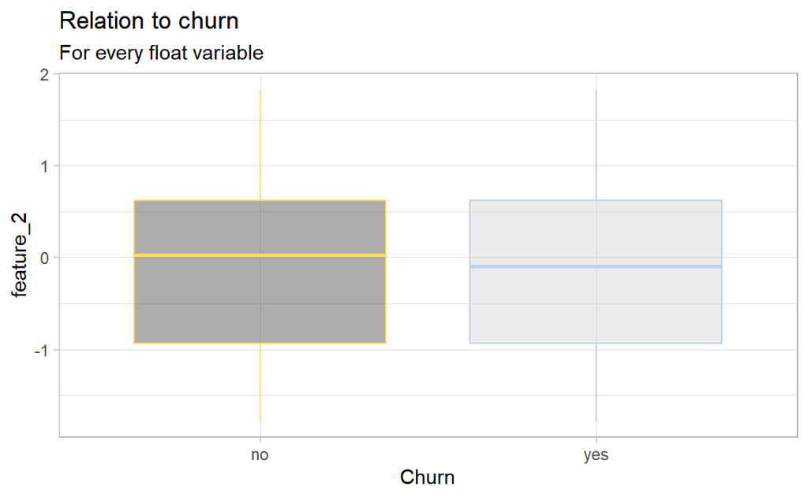

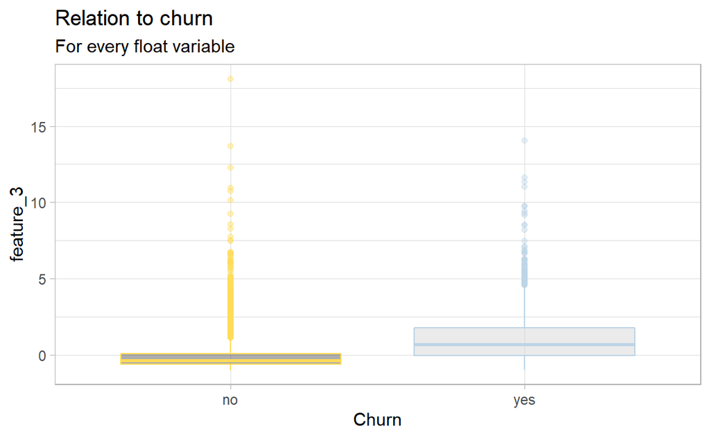

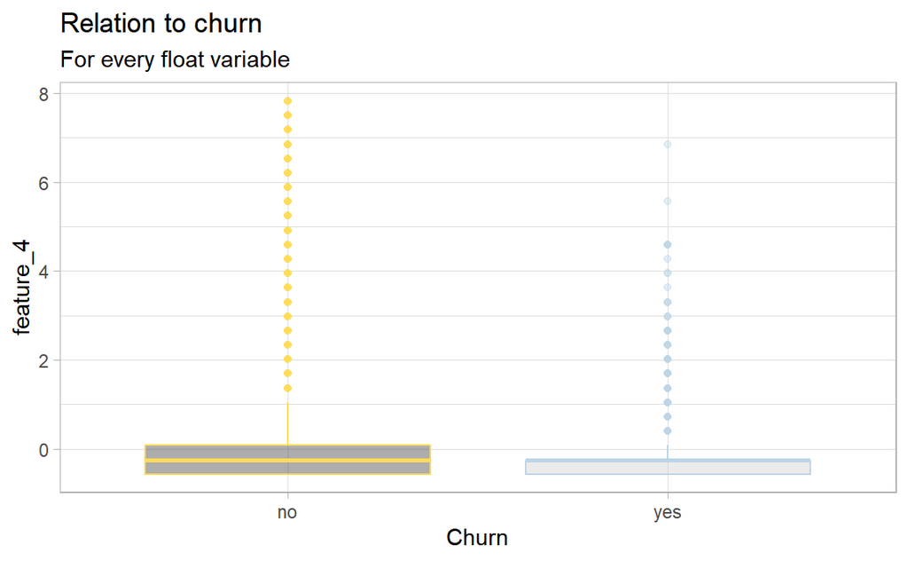

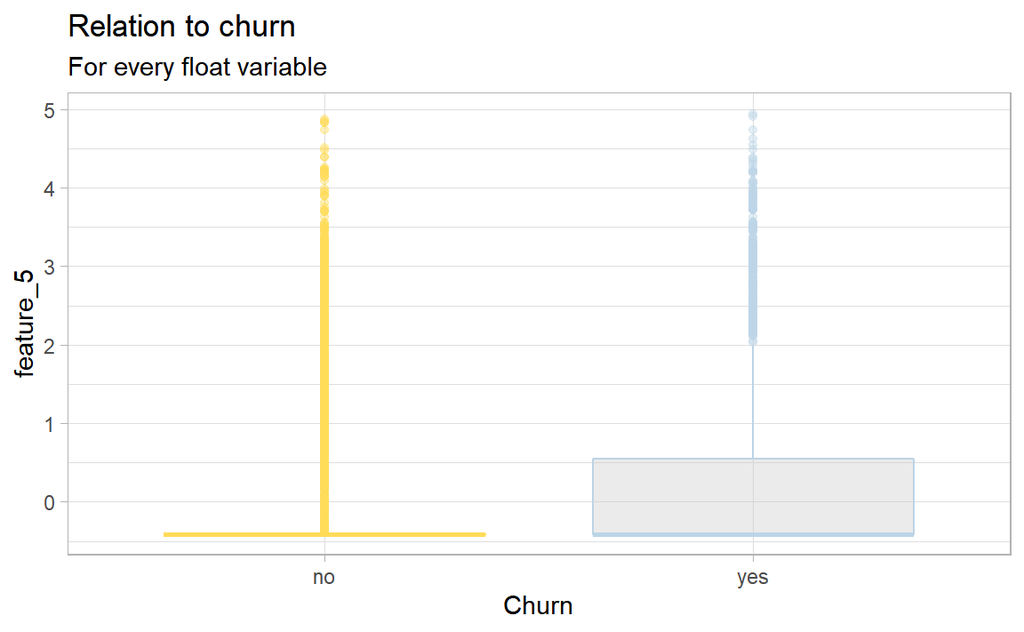

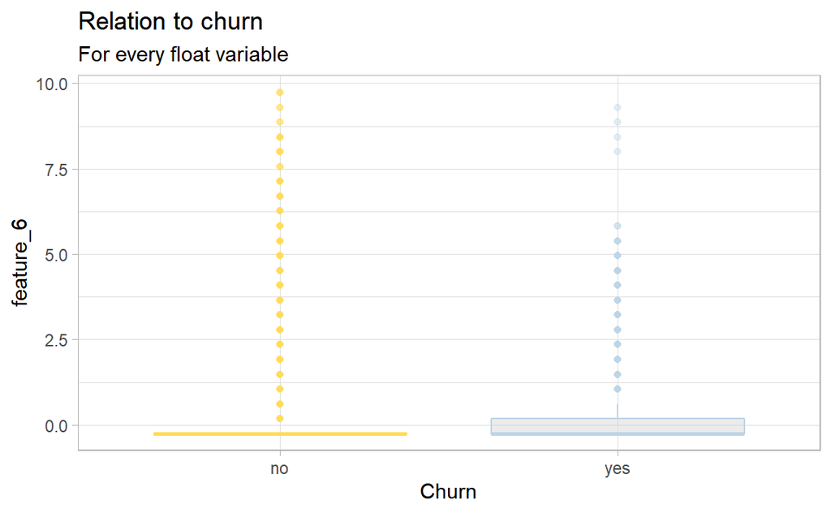

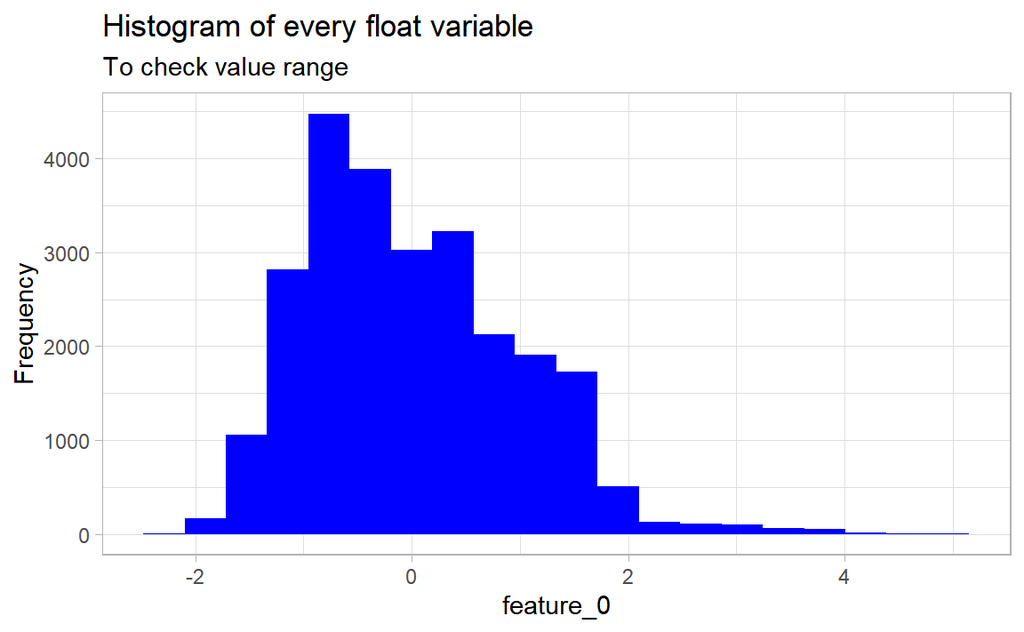

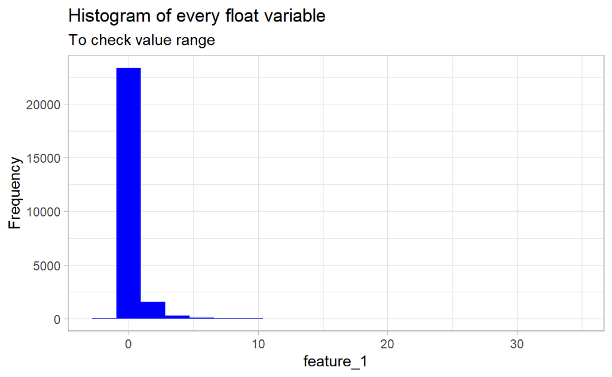

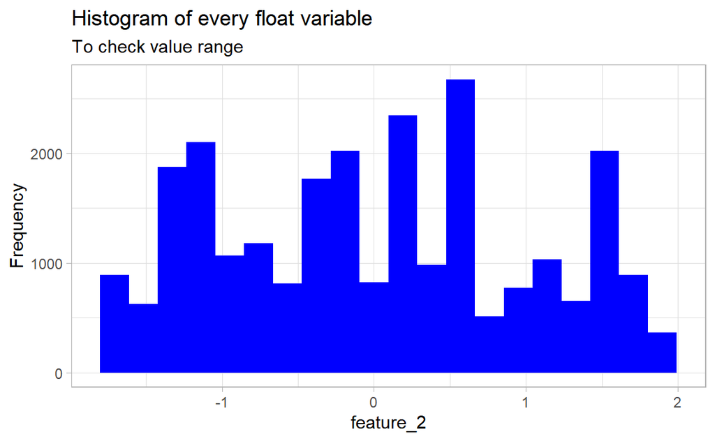

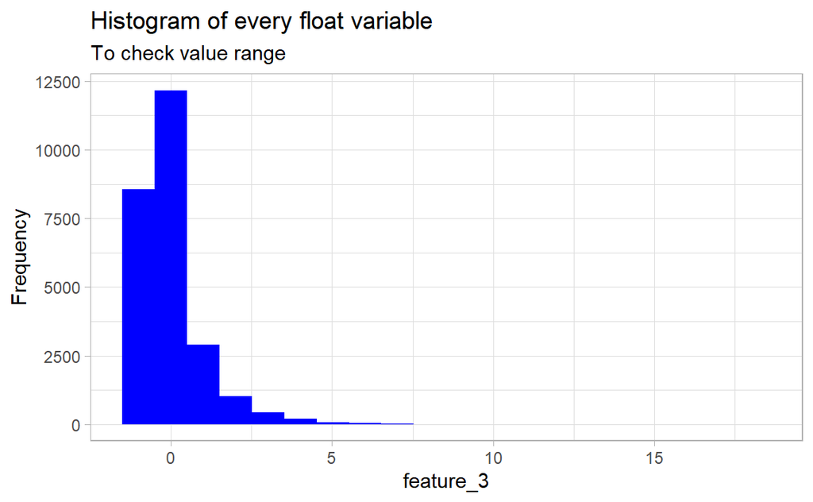

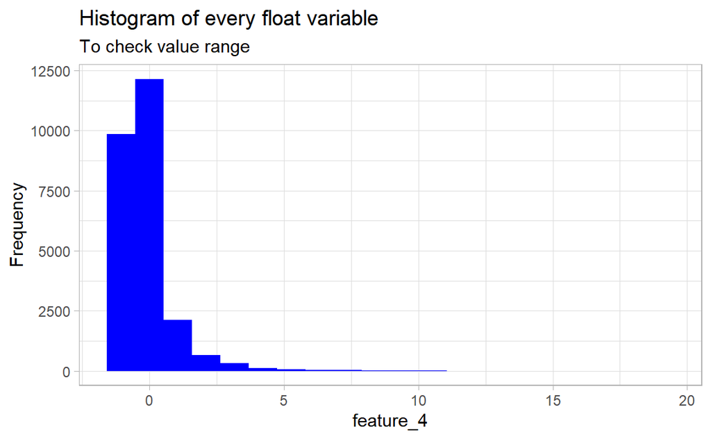

[2 more figures not shown]

This confirms our previous insights from the **Data overview** and **Correlation to churn** section:

- Most of the variables do not affect the churn.
- Only feature_3 has a noticeable impact on churn.
- feature_5 & 6 can be interesting candidates for model training. This will be testes in the **Model** section
- There are alot of outliers present for almost every feature. This can be seen in the histograms - the distributions are positive skewed (Note that features 1, 4, 5 & 6 have been filtered to better display the respective boxplots).
- The scales for float variables are very different.

### 2.7.5 Integer Variables

Next up are the boxplots and histograms for the integer variables.

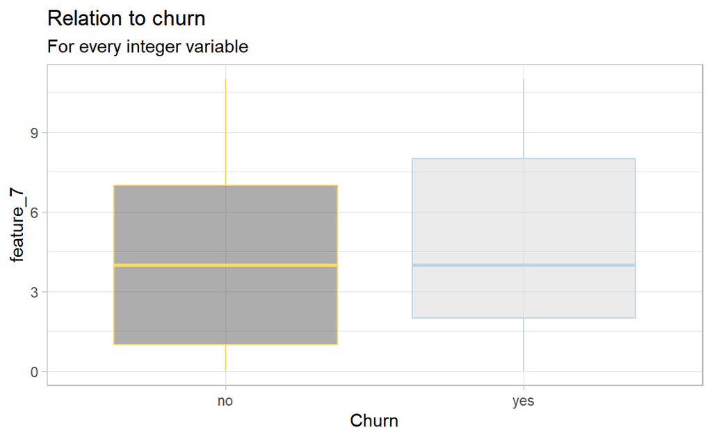

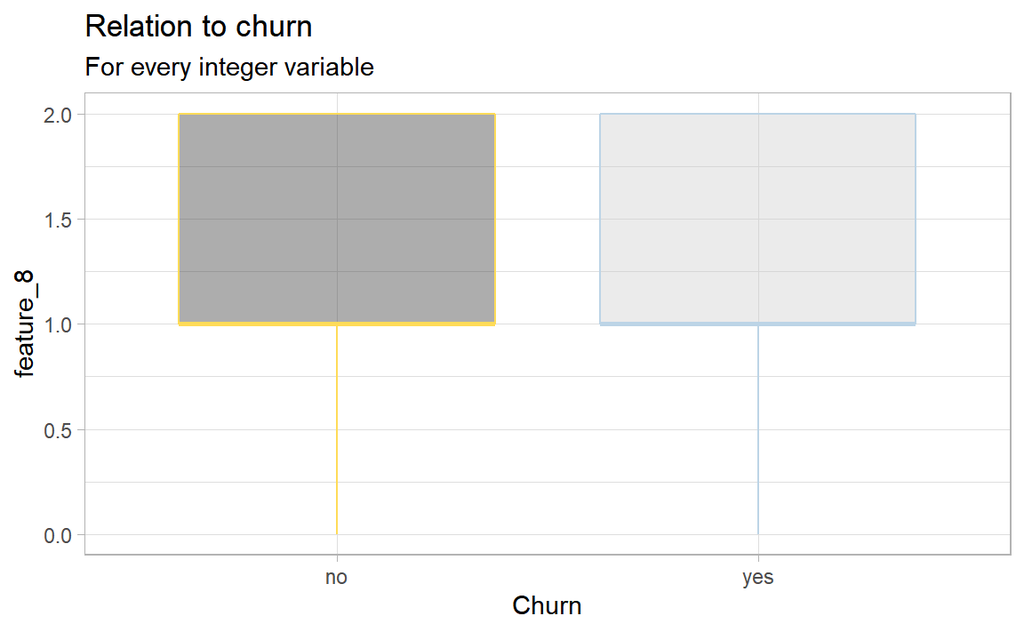

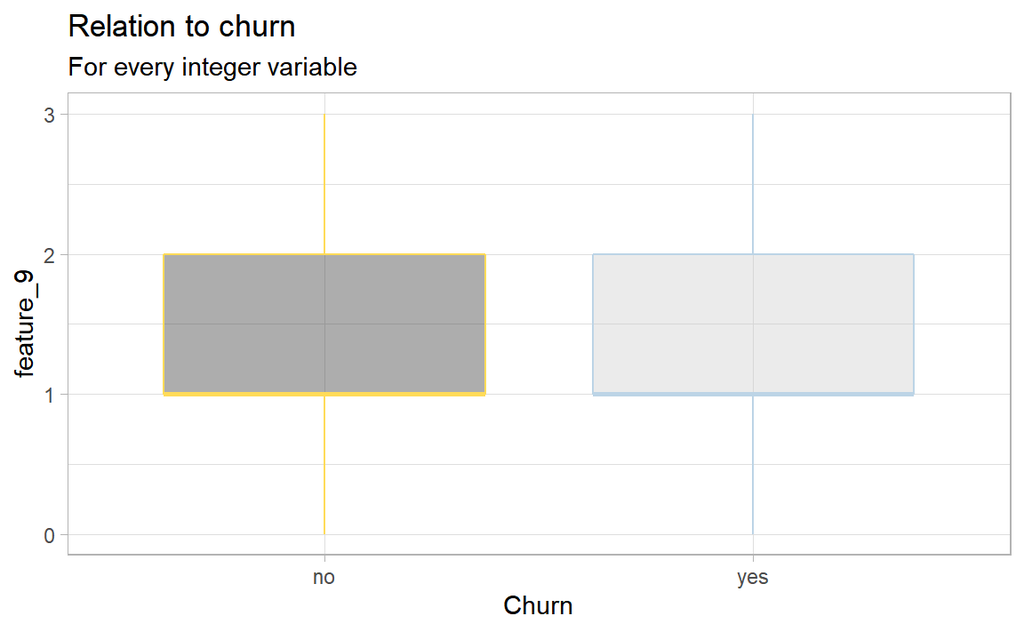

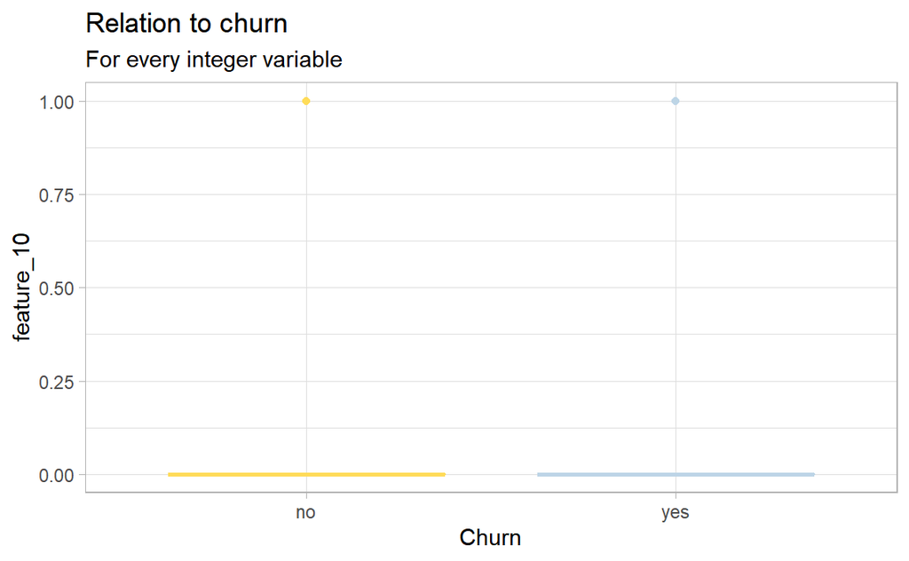

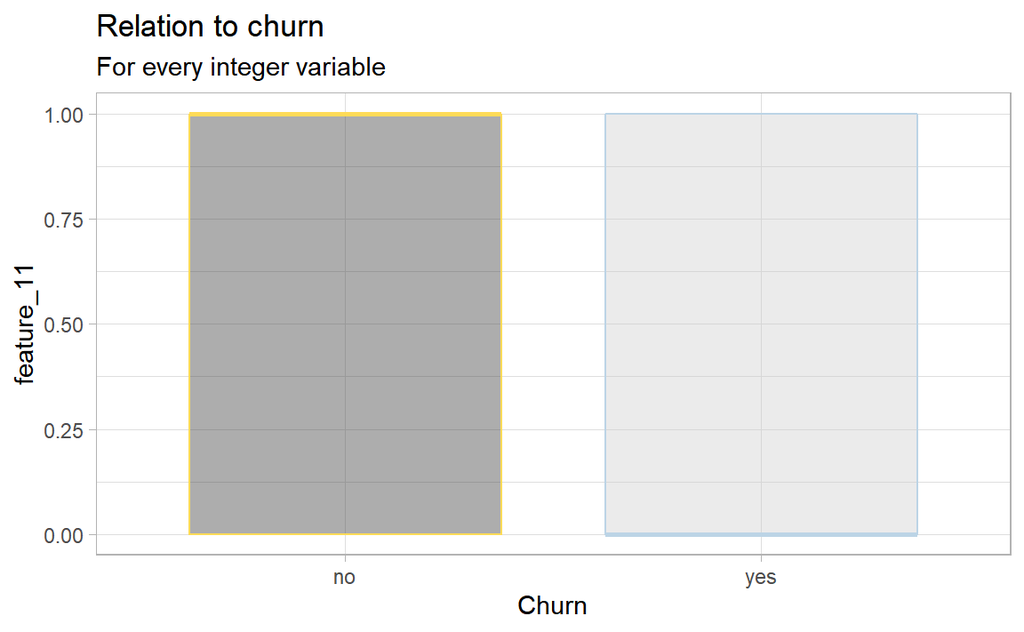

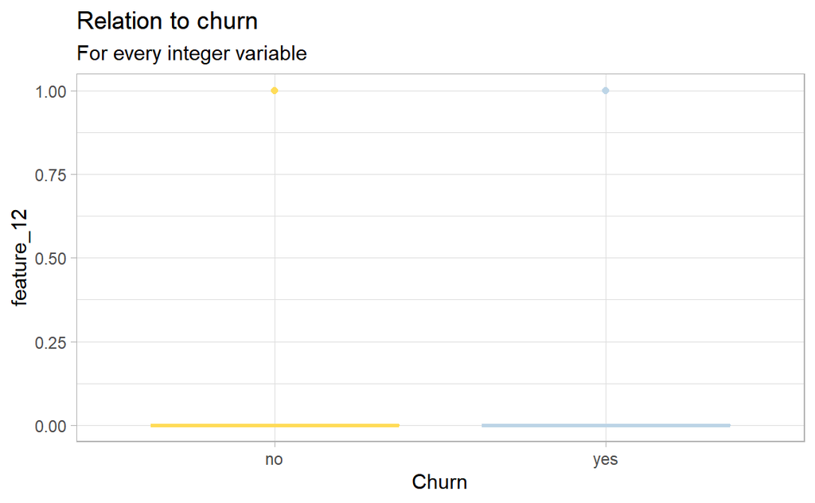

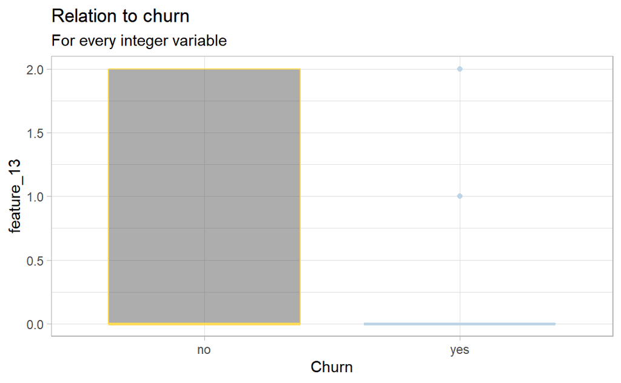

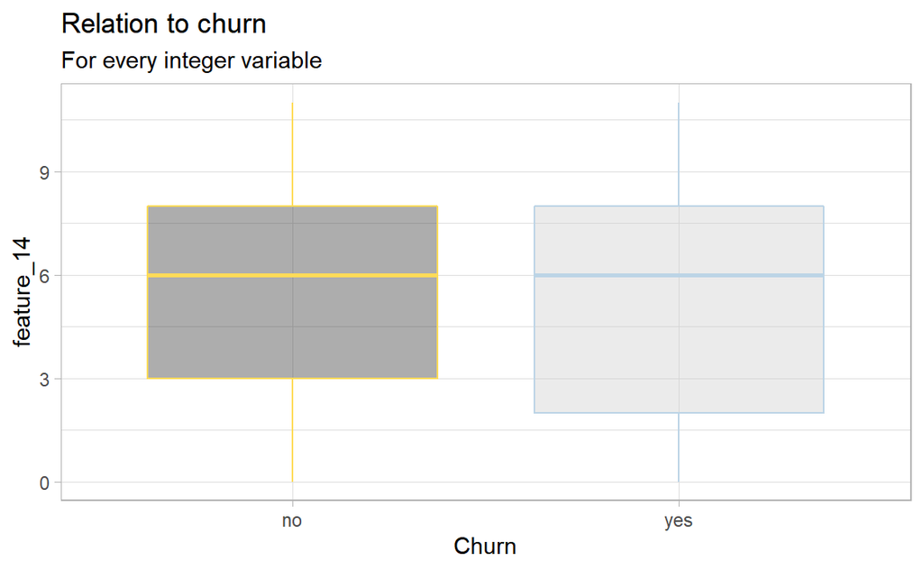

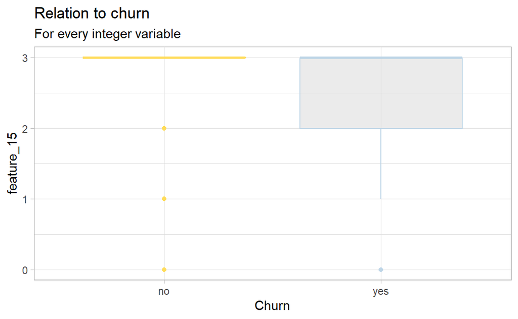

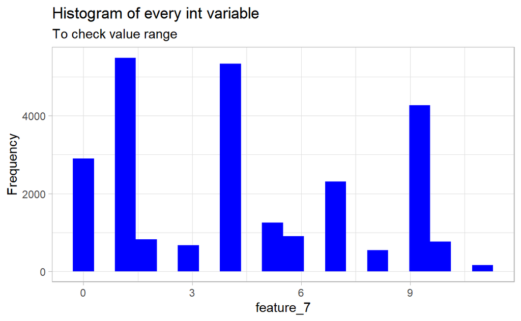

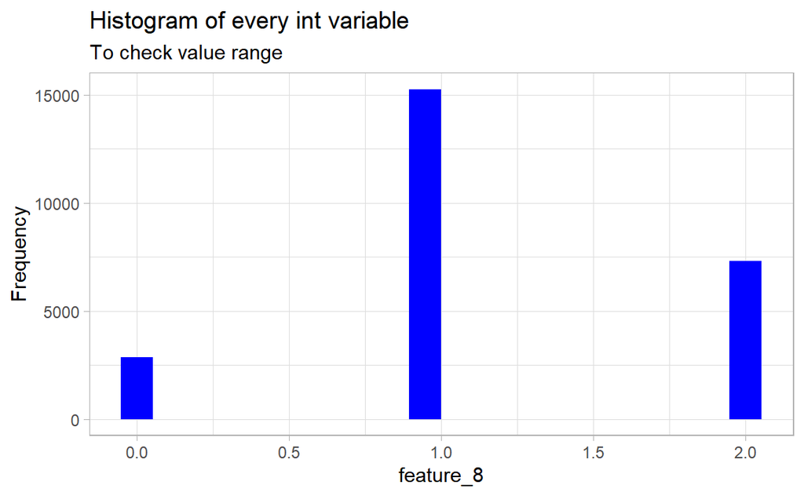

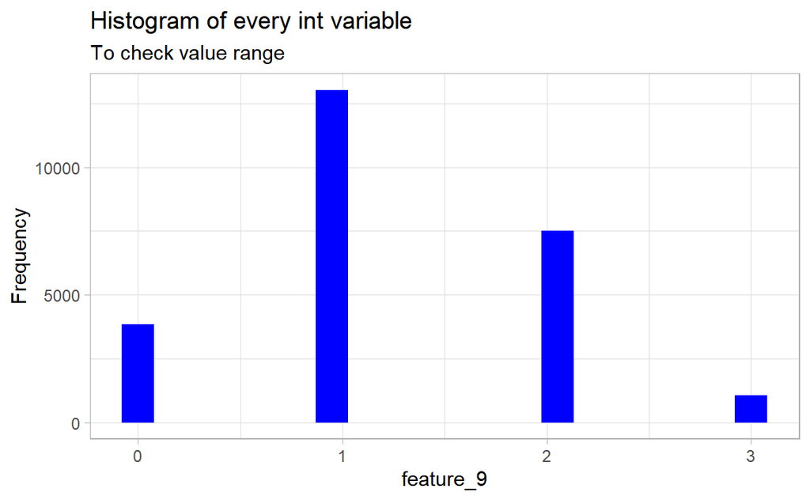

[6 more figures not shown]

Again, this is a confirmation of what we have seen before:

- feature 11 has a noticeable impact on the churn variable.
- feature 13 can also be an interesting candidate for model training. This will be tested in the **Model** section.
- feature 7 - 15 contain discrete integer values, in different levels. feature 10 - 12 contain binary values (0 and 1) for example.
- The scales for integer variables are also different (although not to the same extent as for the float variables).

As a conclusion, we will train our model with

- feature 3
- feature 5
- feature 6
- feature 11
- feature 13

# 3 Data preparation

## 3.1 Select relevant variables

Select the outcome and predictors for our model

```r
df_train_new <-
  df_train %>%
  select(feature_3,
         feature_5,
         feature_6,
         feature_11,
         feature_13,
         churn)

glimpse(df_train_new)
```

```
## Rows: 33,908
## Columns: 6
## $ feature_3  <dbl> -0.012282614, -0.979179166, -0.703477740, -0.039464445, -0.~
## $ feature_5  <dbl> 1.0766475, -0.4114531, -0.4114531, -0.4114531, -0.4114531, ~
## $ feature_6  <dbl> 0.1821975, -0.2519404, -0.2519404, -0.2519404, -0.2519404, ~
## $ feature_11 <dbl> 0, 1, 0, 1, 0, 0, 1, 1, 1, 0, 1, 0, 0, 1, 0, 1, 0, 1, 0, 1,~
## $ feature_13 <dbl> 0, 0, 0, 0, 0, 0, 0, 0, 0, 0, 2, 1, 0, 2, 0, 0, 2, 0, 0, 0,~
## $ churn      <fct> 1, 0, 0, 0, 0, 1, 0, 0, 0, 0, 0, 0, 0, 0, 1, 0, 0, 0, 1, 0,~
```

## 3.2 New Data split

The data split will be done once again on the df_train_new in order to reflect our newest insights. Therefore we need to create another data split.

```r
# Seeded split to provide the same split everytime the split is made to make sure we always use the same data for model training.
set.seed(42)
# Split the data with a 75/25 proportion in favor for the training set
data_split <-
  initial_split(
    df_train_new, # updated data
    prop = 3/4, # 75/25 split
    strata = churn # stratified on churn variable
    )
# Create the dataframes for training and testing
train_data <- training(data_split)
test_data <- testing(data_split)
```

## 3.3 Validation set

For the validation set a k-fold crossvalidation with a set of 5 validation folds will be used. Also, the sample is stratified. This makes sure that every characteristic of the data is properly represented in each sample. The validation set is used in order to check the models performance on the training dataset.

```r
# Fix random generation, also see data split
set.seed(42)
# generate the cross validation set
cv_folds <-
  vfold_cv(train_data,
           v=5, # number of folds
           strata = churn, # ensure the same proportion of the churn variable in every fold
           breaks = 4)
```

## 3.4 Data preprocessing recipe

First we create a recipe for our model that applies the same steps to all data that we feed into our model.

```r
# Create a recipe for our model
churn_rec <-
  recipe(
    # outcome ~ predictor
    churn ~ .,
    data = train_data) %>%
  # perform z-standardization: normalize the numeric variables to have a standard deviation of one and a mean of zero.
  step_normalize(all_numeric(), -all_outcomes()) %>%
  # removes numeric variables that have no variance.
  step_zv(all_numeric(), -all_outcomes()) %>%
  # remove predictor variables that have large correlations with other predictor variables.
  step_corr(all_predictors(), threshold = 0.7, method = "spearman")
```

These variables with respective roles will be used by our recipe.

```r
summary(churn_rec)
```

| variable | type | role | source |
| --- | --- | --- | --- |
| feature_3 | numeric | predictor | original |
| feature_5 | numeric | predictor | original |
| feature_6 | numeric | predictor | original |
| feature_11 | numeric | predictor | original |
| feature_13 | numeric | predictor | original |
| churn | nominal | outcome | original |

We check how the recipe will affect our training data

```r
prepped_data <-
  churn_rec %>% # use the recipe object
  prep() %>% # perform the recipe on training data
  juice() # extract only the preprocessed dataframe


glimpse(prepped_data)
```

```
## Rows: 25,430
## Columns: 5
## $ feature_3  <dbl> -0.98232820, -0.70598997, -0.09882429, -0.32456537, 1.01820~
## $ feature_6  <dbl> -0.3003303, -0.3003303, -0.3003303, -0.3003303, -0.3003303,~
## $ feature_11 <dbl> 0.8951775, -1.1170530, -1.1170530, 0.8951775, 0.8951775, 0.~
## $ feature_13 <dbl> -0.7135851, -0.7135851, -0.7135851, -0.7135851, -0.7135851,~
## $ churn      <fct> 0, 0, 0, 0, 0, 0, 0, 0, 0, 0, 0, 0, 0, 0, 0, 0, 0, 0, 0, 0,~
```

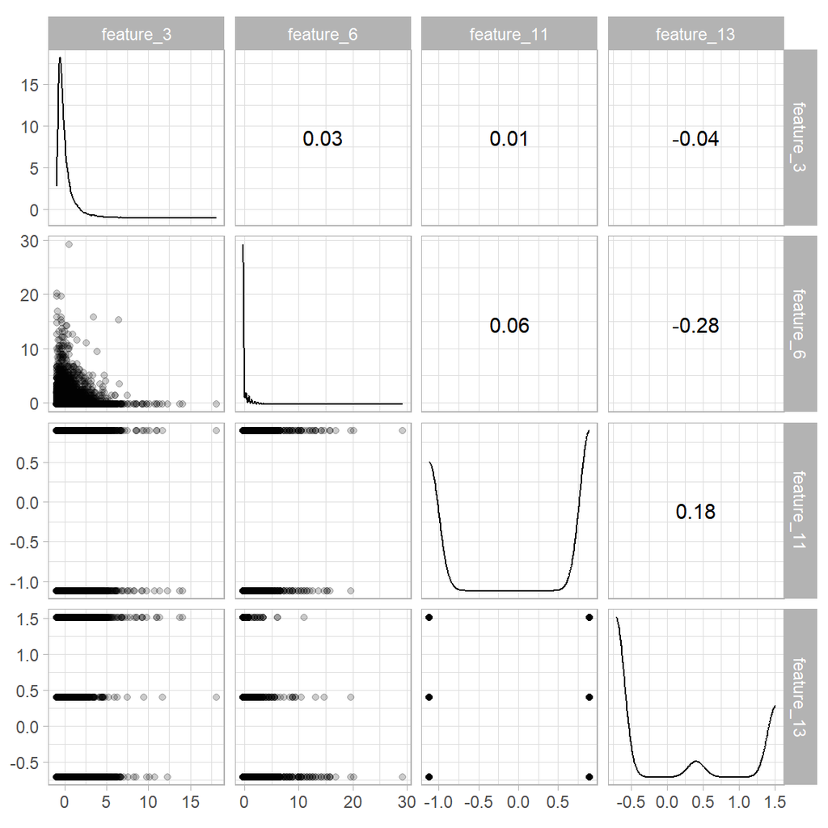

```r
prepped_data %>%
  select(-churn) %>%
  ggscatmat(corMethod = "spearman",
            alpha=0.2)
```

The recipe is prepared such that the churn variable serves as the outcome which the model should predict. We can see that feature_5 has been removed. This happened by the step_corr() function in the recipe meaning feature_5 correlates with another feature and is not providing useful information in model training.

# 4 Model - XGBoost

## 4.1 Model specification

We will set up the models with the needed specification. The function boost_tree automatically uses the empirically best parameters if none are specified.

We also use the xgboost engine with the classification mode.

```r
xgb_spec <-
  boost_tree() %>%
  # model engine
  set_engine("xgboost") %>%
  # model mode
  set_mode("classification")

# show model specification
xgb_spec
```

```
## Boosted Tree Model Specification (classification)
##
## Computational engine: xgboost
```

## 4.2 Workflow

```r
# workflow pipeline
xgb_wflow <-
  workflow() %>%
  # specifiy our recipe
  add_recipe(churn_rec) %>%
  # and our model
  add_model(xgb_spec)

# show workflow
xgb_wflow
```

```
## == Workflow ====================================================================
## Preprocessor: Recipe
## Model: boost_tree()
##
## -- Preprocessor ----------------------------------------------------------------
## 3 Recipe Steps
##
## * step_normalize()
## * step_zv()
## * step_corr()
##
## -- Model -----------------------------------------------------------------------
## Boosted Tree Model Specification (classification)
##
## Computational engine: xgboost
```

## 4.3 Model execution

Finally we can execute our model and fit it to our training data with the finalized workflow.  
Our validation set cv_folds is used to estimate the performance for specified metrics and computed by the fit_resamples function. In particular this is done by fitting the model to each resample while holding out a portion of the dataset from each resample on which the model is then evaluated.  
We save the predictions made so we can evaluate the performance metrics, especially the f1 score.

```r
# Create fit to the model and check with validation folds

xgb_res <-
  xgb_wflow %>%
  fit_resamples(
    resamples = cv_folds,
    # Define metrics
    metrics = metric_set(
      f_meas,
      accuracy,
      roc_auc,
      recall,
      precision,
      # spec,
      # sens,
      ),
    # Save predictions
    control = control_resamples(save_pred = TRUE)
  )
```

## 4.4 Model evaluation

To evaluate our model, we collect the performance metrics with collect_metrics().

First we take a look at the performance over all folds

```r
xgb_res %>%
  collect_metrics(summarize = TRUE)
```

| .metric | .estimator | mean | n | std_err | .config |
| --- | --- | --- | --- | --- | --- |
| accuracy | binary | 0.8924105 | 5 | 0.0015056382 | Preprocessor1_Model1 |
| f_meas | binary | 0.9408938 | 5 | 0.0008361253 | Preprocessor1_Model1 |
| precision | binary | 0.9136662 | 5 | 0.0012743246 | Preprocessor1_Model1 |
| recall | binary | 0.9698063 | 5 | 0.0016035156 | Preprocessor1_Model1 |
| roc_auc | binary | 0.8733081 | 5 | 0.0028505687 | Preprocessor1_Model1 |

Our models performance overall seems to be good. The only problem is that the specificity is very poor.

We then collect our predictions. This will be needed to create the confusion matrix and ROC curve

```r
xgb_pred <-
  xgb_res %>%
  collect_predictions()
```

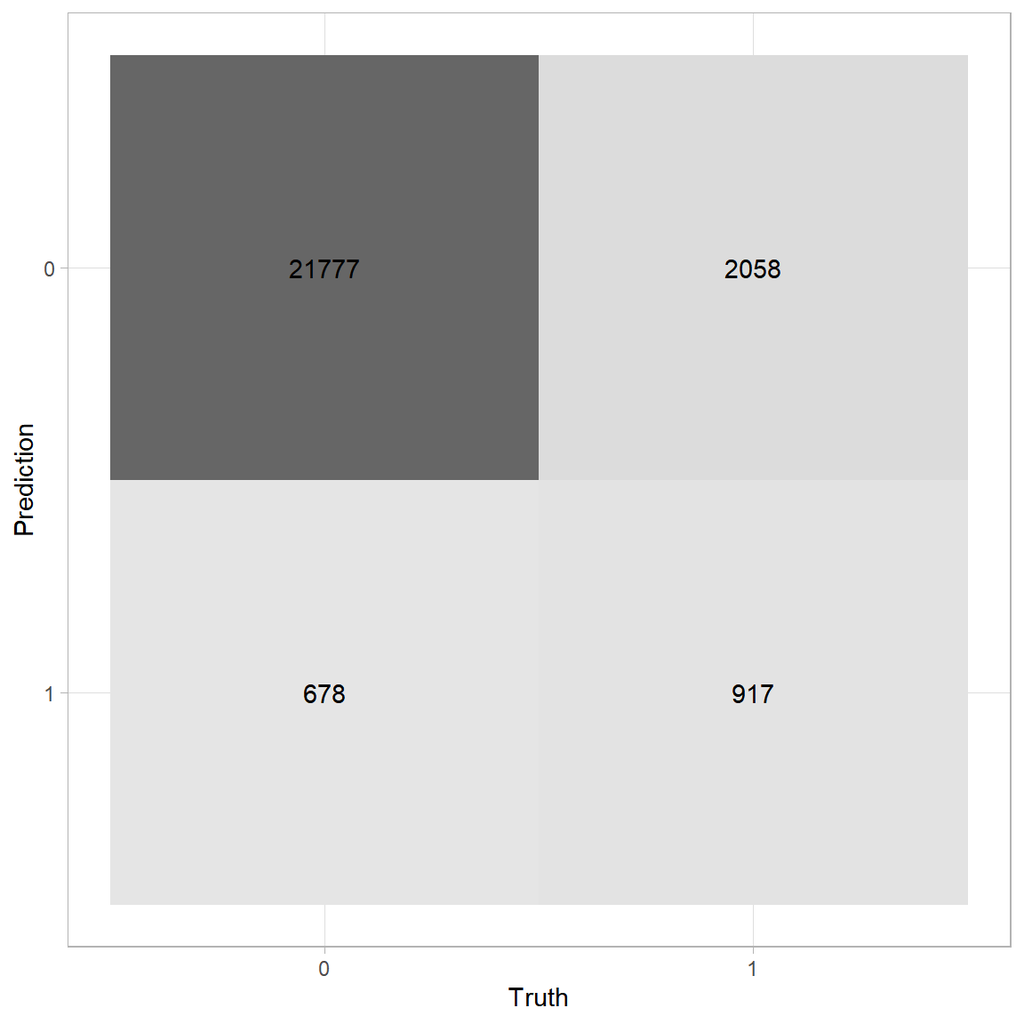

```r
xgb_pred %>%
  conf_mat(churn, .pred_class) %>%
  autoplot(type = "heatmap")
```

Overall our model has a high rate of true positives but (as we have seen already) a low specificity - rate of true negatives.